# Table Exploration

## Preliminaries

We will start to look at different columns and see how they can help us predict survival. During this module, I'll be building new tables that are a subset of the bigger titanic_table. For instance, perhaps I'll build a table of only female passengers. Or a table with only passengers under the age of 10. Or even a table of female passengers under the age of 10. I'll try to name these tables with something that helps me keep track of what I am doing. I'll have lots of tables floating around (might be a Titanic pun there some place).

Here is the code to set up our table to get started. I add a new line at top that tells the notebook to show what we plot in the notebook. More on plotting later. For now know that you have to put this line as first piece of code in your notebook to see your plots.

```python
%matplotlib inline

from csv import DictReader

from urllib2 import urlopen

url = 'https://docs.google.com/spreadsheets/d/1z1ycUZjJpmMWB4gXbhwRQ9B_qa42CwzAQkf82mLibxI/pub?output=csv'

response = urlopen(url)

titanic_table = [row for row in DictReader(response)]

print(titanic_table[0])  # print the first row of the table - Mr. Braund
```

```
{'Fare': '7.25', 'Name': 'Braund, Mr. Owen Harris', 'Embarked': 'S', 'Age': '22', 'Parch': '0', 'Pclass': '3', 'Sex': 'male', 'Survived': '0', 'SibSp': '1', 'PassengerId': '1', 'Ticket': 'A/5 21171', 'Cabin': ''}
```

## Building sub-tables

To produce a new table from an existing table calls for a filtered map. We can filter out the passengers we are not interested in. Let's get a start with gender. Let's build a female table. Notice that I am copying over the entire row to the new table - I am using an identity map.

```python
female_table = [row for row in titanic_table if row['Sex'] == 'female']
len(female_table)  # 314 female passengers
```

```
314
```

## Female survivors

My next question is how many females survived. In the last module, I did a map to get the Survived column then a reduce using sum to get the count. I'll do that again for practice here but then look at a different way of getting similar results.

One caveat: I am going to combine two map operations into one. In the prior module I used a map to pull out a column and then another map to produce a numeric value from a string. My one map below does both: it pulls out the Survived value and then converts it to an int and then copies it to the new list. If you feel more comfortable doing it as 2 separate maps, no problem.

And note that we are working with the sub-table `female_table`, not the larger `titanic_table`.

```python
female_survival = [int(row['Survived']) for row in female_table]
female_survivor_count = sum(female_survival)
female_survival_percentage = float(female_survivor_count)/len(female_table)
print(female_survival_percentage)  # .74 - wow
```

```
0.742038216561
```

So female passengers had twice the survival rate as all passengers taken together.

## Getting ready for plotting

We could continue to compute percentages and print them out. But sometimes it is more powerful to visualize data in a plot or graph. We are going to need to add a package to Python to do visualization. The package is called `matplotlib`. The *lib* is pronounced as in *bib*. Here is the line of code I will use to pull the package in so I can use it.

```
import matplotlib.pyplot as plt
```

You will notice that I actually import from `matplotlib.pyplot`. Python allows me to choose sub-packages using the dot notation. In essence we are saying look in the (big!) matplotlib package for the sub-package called pyplot - that is the one I want.

The import statement looks a bit odd. We have seen `from math import sqrt`. I could do something similar here, i.e., import all the functions I will be using. However, it is such standard practice in the python community to use the `import as` format for `matplotlib` that I feel loathe to break it.

So what does `import as` do. It imports *all* functions in the pyplot sub-package. Similarly, if I did `import math` I would get all math functions imported. The downside of using import this way is that you have to prefix each function you use with the full package name. I'll give you a couple examples below using math.

```python
from math import sqrt  # what we have seen up until now

print(sqrt(2.7))  # no prefix needed
```

```
1.64316767252
```

```python
import math  # new - pulls in all functions but have to prefix

print( math.sqrt(2.7))  # notice I now need prefix
```

```
1.64316767252
```

```python
import math as my_math  # new - gives nickname to package

print( my_math.sqrt(2.7))  # still have to use nickname
```

```
1.64316767252
```

Getting back to matplotlib, if I wanted to use a function called `hist` from the package, I would need to write `matplotlib.pyplot.hist()`. Yuck. To make it more palatable, I can give a nickname to that full path, in this case `plt`. As you will see, I still need to prefix functions from the package but now get to use `plt.hist()`. A little better. BTW: the use of `plt` is also standard. You could choose your own variable nickname but stick with `plt` to make your life easier.

## Plotting female survivors

The plotting functions we will use all take one or more lists of values as arguments then plot those values and give us a visualization. We will use our normal way of producing those lists by mapping columns from a table. And we already have a list of survival values in `female_survival`. Let's try using a histogram (using `plt.hist`) to see what things look like.

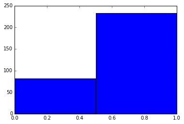

```python
import matplotlib.pyplot as plt

plt.hist(female_survival, 2)  #list of values, number of bins to use

plt.show()
```

Kind of rough around the edges but not bad. The `hist` function takes a list of numeric values and a number of "bins". It divides the x axis into the bins and then shows with a bar how many values fall in each bin. We only have 2 bins, 0 and 1.

## Let's clean up the plot

The problem with the plot above is that I don't know what the visualization means without looking at the code that produced it. I'd like to label the axis and also the plot as a whole. The ticks on the x axis are also odd, being in decimal places. I'll add some code to do clean-up.

Before I get to the code, you need some background on how plotting works. Up until now we have been assigning values to variables. As you can see below, there are no assignment statements. What is happening is that the plt package is working in the background to get our plot ready for us. We give it instructions by calling functions. When we are ready, we tell plt to go ahead and `show` us what it has. Again, it is a type of pipeline or workflow that is typical of many Python packages.

As you can see, I am putting a label on the x-axis and the y-axis. I am also giving a title to the whole plot. You can choose whatever strings for these that make sense to you.

The last thing I do is to specify that I want the ticks 0 and 1 on the x-axis to replace the default decimal values.

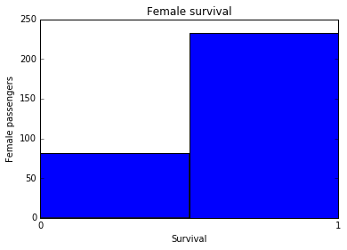

```python
#import matplotlib.pyplot as plt - only need to import once in notebook

plt.hist(female_survival, 2)  # same as before
plt.xlabel("Survival")
plt.ylabel("Female passengers")
plt.title("Female survival")
plt.xticks([0,1])  # a list of ticks

plt.show()  # ok, ready to see what it looks like
```

## Jumping the rabbit hole

I am going to say I am happy with the plot I have. Could I clean it up further? Absolutely. I could center the ticks on the x-axis. I could change fonts on the labels, e.g., make the text larger. I could move the title up farther. I could color code the bars. There are entire books and video courses on using matplotlib plus plenty of free tutorials and advice on the web. It is safe to say that if you have a visual bent, you will have plenty of room to explore using the many features of matplotlib, i.e., go down the rabbit hole. I am going to get back to our prediction problem.

## Male survivors

My next question is how many males survived. We can copy and paste the code from female survivors and just make a few changes.

```python
male_table = [row for row in titanic_table if row['Sex'] == 'male']
male_survival = [int(row['Survived']) for row in male_table]
male_survivor_count = sum(male_survival)
male_survival_percentage = float(male_survivor_count)/len(male_table)
print(male_survival_percentage)  # .19 - double wow
```

```
0.188908145581
```

Now let's plot it.

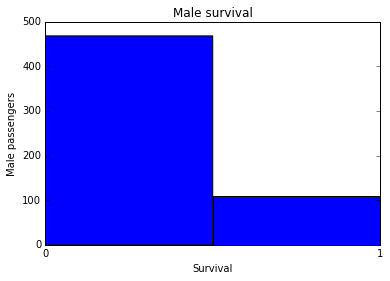

```python
#import matplotlib.pyplot as plt

plt.hist(male_survival, 2)
plt.xlabel("Survival")
plt.ylabel("Male passengers")
plt.title("Male survival")
plt.xticks([0,1])

plt.show()
```

## Where was everyone berthed?

Let's see how passengers were divided up among the 3 cabin classes. Now I have 3 values so ask for 3 bins. Historical note: 3rd class was at the bottom of the ship.

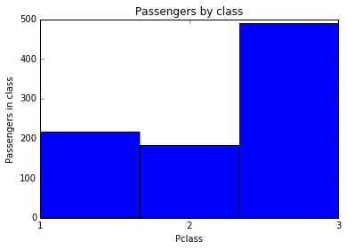

```python
pclass = [int(row['Pclass']) for row in titanic_table]

plt.hist([pclass], 3)  # ask for 3 bins to match 3 classes
plt.xlabel("Pclass")
plt.ylabel("Passengers in class")
plt.title("Passengers by class")
plt.xticks([1,2,3])  # use 3 ticks to match 3 classes

plt.show()
```

## How did 3rd class passengers fare?

I'll build a sub-table for 3rd class passengers then check survivability. This is very similar to what we did for female passengers.

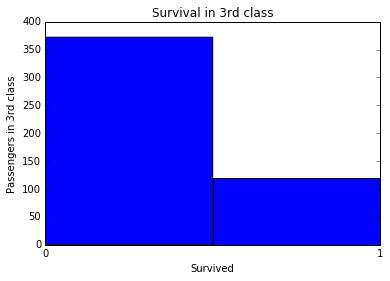

```python
class3_table = [row for row in titanic_table if row['Pclass'] == '3']
class3_survival = [int(row['Survived']) for row in class3_table]

plt.hist(class3_survival, 2)
plt.xlabel("Survived")
plt.ylabel("Passengers in 3rd class")
plt.title("Survival in 3rd class")
plt.xticks([0,1])

plt.show()
```

## Females in 3rd class

Let's do one more. I have two tables, one of females only, one of 3rd class only. I'd like to look at the intersection of the two tables: females in 3rd class. Python does have a set intersection function, but we would have to jump through hoops to use it. I'll just use what we already know and build a new sub-table that represents the intersection. Notice I am using the `class3_table` as a starting point for the first filtered map.

```
144
```

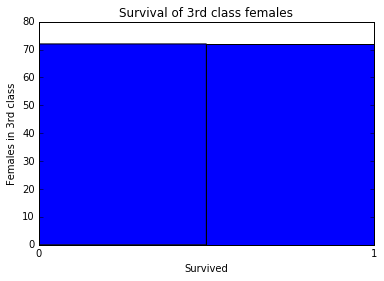

```python
fem3_table = [row for row in class3_table if row['Sex'] == 'female']
fem3_survival = [int(row['Survived']) for row in fem3_table]

print(len(fem3_table))  # 144 total

plt.hist(fem3_survival, 2)
plt.xlabel("Survived")
plt.ylabel("Females in 3rd class")
plt.title("Survival of 3rd class females")
plt.xticks([0,1])

plt.show()
```

Almost 50/50 out of 144 3rd class female passengers.

## Next up

We will continue exploring the data and add a few twists. We are getting close to building our first predictor!